# Тестовое задание

**Младший исследователь данных (DS NLP)**

**Бизнес-кейс**

Одним из приоритетов нашего бизнеса является создание лучшего клиентского опыта, поэтому для компании важно понимать текущий уровень CSI (customer satisfaction index) и его динамику (для оценки эффекта изменений в бизнес-процессах). С этой целью, разработан автоматический механизм сбора обратной связи по заказам. Кроме общей оценки удовлетворённости, клиенты оставляют обратную связь в виде текстового комментария/отзыва в свободной форме.

Вам необходимо обучить модель классификации негативных отзывов, которая позволит получать детальную аналитику по проблемам клиентов в автоматическом режиме.

**Описание датасета**

Dataset представляет собой подвыборку негативных комментариев клиентов по заказам с типом получения «самовывоз из магазина» с разметкой на 8 классов проблем.

**Файл DS_NLP.xlsx**  
`text` - текст отзыва клиента  
`class` - метка класса на которую надо обучиться  
`ID` - колонка нужна только для проверяющих, не используйте её в задании

**Постановка задачи и оформление результатов**

Построить модель классификации (`multiclass, 8 классов`) для отзывов клиентов.  
Для этого проведите исследование с обучением различных моделей, используя известные вам подходы. Визуализируйте промежуточные и итоговые результаты, замерьте метрики и сделайте финальные выводы.  
Работу нужно оформлять в `jupyter notebook`, снабдив комментариями.  
Метрика для оценки - `f1`.  
Готовая модель должна быть сохранена в каком-либо формате.  
В отдельном файле `model.py` должна храниться функция:

```
def get_result(text: pd.Series) -> pd.Series:
    pass
```

Функция принимает колонку с отзывами, на выходе отдаёт колонку с предсказанными классами. Колонка с классами должна иметь наименование `class_predicted`. Функция должна выполнять предобработку текста (если она есть), вызывать обученную модель из файла, предсказывать классы и отдавать их.  
Также, финальная посылка результатов должна обязательно содержать файл `requirements.txt` с перечнем библиотек и версиями, которые вы использовали.  
Файл должен быть в таком виде, чтобы командой:`pip install -r requirements.txt` устанавливались все ваши зависимости в отдельное окружение.

**Внимание! Перед отправкой готовых результатов, внимательно проверяйте и тестируйте работоспособность.**

Для этого:

- создайте с помощью requirements новое окружение и кернел
- запустите на нем свой юпитер ноутбук и итоговую функцию для проверки корректной выдачи результатов.

**План проекта**

**1. Изучение данных.**

1.1 Установка библиотек.  
1.2 Импорт библиотек и методов работы с данными.  
1.3 Считывание данных из файлов.

**2. Предобработка данных.**

2.1 Проверка данных на наличие пропусков и дубликатов.  
2.2 Приведение слов к нижнему регистру, токенизация и удаление стоп-слов.

**3. Анализ данных.**

3.1 Исследование баланса классов.  
3.2 Анилиз длин текстов.  
3.3 Частотный анализ текстов.

**4. Подготовка данных.**

4.1 Разделение данных на выборки.  
4.2 Рассчт эмбедингов.

**5. Обучение и анализ моделей.**

5.1 Написание функций.  
5.2 Исследование модели логистической регрессии.  
5.3 Исследование модели случайного леса.  
5.4 Исследование модели градиентного бустинга.

**6. Проверка лучшей модели.**

6.1 Проверка модели на тестовой выборке.  
6.2 Проверка модели на адекватность предсказаний.

**7. Вывод.**

## Изучение данных

### Выполним импорт нужных библиотек и методов работы с данными.

```python
# Импорт стандартных библиотек
import warnings
import re

# Импорт сторонних библиотек
import pandas as pd
import numpy as np
import matplotlib.pyplot as plt
import seaborn as sns
import optuna
#import torch
import joblib

# Отключение предупреждений
pd.options.mode.chained_assignment = None
warnings.filterwarnings('ignore')
```

```python
# Импорт моделей машинного обучения
from sklearn.linear_model import LogisticRegression
from sklearn.ensemble import RandomForestClassifier
from lightgbm import LGBMClassifier
from sklearn.dummy import DummyClassifier

#from sklearn.preprocessing import LabelEncoder

# Импорт способов работы с выборками и построения кривых обучения
from sklearn.model_selection import (train_test_split,
                                     cross_val_predict,
                                     StratifiedKFold)

# Импорт метрик
from sklearn.metrics import (roc_auc_score,
                             f1_score,
                             classification_report,
                             confusion_matrix,
                             ConfusionMatrixDisplay)

# Импорт способов векторизации текстов
#from sklearn.feature_extraction.text import CountVectorizer
#from sklearn.feature_extraction.text import TfidfVectorizer

# Импорт предобученной модели для получения эмбедингов
from sentence_transformers import SentenceTransformer

# Импорт индикатора выполнения
from tqdm import notebook

# Импорт токенайзера и стоп - слов из nltk
from nltk import word_tokenize
from nltk.corpus import stopwords

# Импорт библиотеки для создания визуализации частотности слов
from wordcloud import WordCloud

# Импорт способа использования синтаксиса Markdown при вводе текста в ячейке
from IPython.display import Markdown

# Задание константы (Ответ на главный вопрос жизни, вселенной и всего такого)
RANDOM_STATE = 42
```

### Считываем данные из `xlsx-файла` в датафрейм и сохраняем в переменную.

```python
df = pd.read_excel('../data/DS_NLP.xlsx', index_col=0)
df
```

|  | id | text | class |
| --- | --- | --- | --- |
| 0 | 45 | негатив к вам и горячей линии которые нафиг н... | Консультация КЦ |
| 1 | 97 | перестаньте впаривать клиентам дополнительные ... | Компетентность продавцов/ консультантов |
| 2 | 105 | продавец предложил наклеить защитную плёнку з... | Компетентность продавцов/ консультантов |
| 3 | 127 | продавец режил продать нам товар почему то по ... | Компетентность продавцов/ консультантов |
| 4 | 130 | навязанные услуги ( без моего согласия) на сум... | Компетентность продавцов/ консультантов |
| ... | ... | ... | ... |
| 2832 | 17570 | почему отключили электронную очередь через пол... | Электронная очередь |
| 2833 | 17579 | очередь на кассе. продавцы не торопятся с зака... | Время ожидания у кассы |
| 2834 | 17586 | профессионализма менеджеру бы, да и внимания к... | Обслуживание продавцами/ консультантами |
| 2835 | 17591 | сотрудник на выдаче заказа потребовал документ... | Электронная очередь |
| 2836 | 17594 | клиентоориентированность | Компетентность продавцов/ консультантов |

2837 rows × 3 columns

**Замечание:**  
В нашей таблице 2837 строк. Целевой признак находится в колонке `class`. Тексты комментариев находятся в колонке `text`.

## Предобработка данных.

### Проверим данные на пропуски и дубликаты.

```python
# Проверка данных на пропуски
df.isna().sum()
```

```
id       0
text     0
class    0
dtype: int64
```

```python
# Проверка данных на дубликаты.
print(f'Обнаружено дубликатов: {df[["text", "class"]].duplicated().sum()}')
```

```
Обнаружено дубликатов: 15
```

```python
# Вывод строк с дубликатами
df[df[['text', 'class']].duplicated()]
```

|  | id | text | class |
| --- | --- | --- | --- |
| 173 | 1151 | очередь на кассе | Время ожидания у кассы |
| 1089 | 6726 | очередь на кассе | Время ожидания у кассы |
| 1306 | 8131 | навязывание дополнительных услуг | Компетентность продавцов/ консультантов |
| 1496 | 9322 | хамское отношение персонала | Вежливость сотрудников магазина |
| 1518 | 9445 | хамское отношение персонала | Вежливость сотрудников магазина |
| 1556 | 9652 | долго ждала сотрудника | Доступность персонала в магазине |
| 1724 | 10685 | не в лучшую сторону внесены изменения выдачи и... | Электронная очередь |
| 1774 | 11004 | неприветливый персонал | Компетентность продавцов/ консультантов |
| 1798 | 11159 | некомпетентный персонал | Компетентность продавцов/ консультантов |
| 2111 | 13216 | хамское отношение персонала | Вежливость сотрудников магазина |
| 2212 | 13715 | грубый продавец | Вежливость сотрудников магазина |
| 2560 | 15877 | хамское обслуживание | Обслуживание на кассе |
| 2583 | 16045 | не вежливый продавец | Компетентность продавцов/ консультантов |
| 2600 | 16152 | в магазине в парк хаус очень долго выдают гото... | Доступность персонала в магазине |
| 2715 | 16806 | вежливость сотрудников - 0. | Вежливость сотрудников магазина |

```python
# Удалим строки - дубликаты
df = df[~df[['text', 'class']].duplicated()]
df.shape
```

```
(2822, 3)
```

**Замечание:**  
Пропусков данных нет. Обнаружили 15 строк дубликатов. У них отличаюся только значения `id`. Скорее всего они появились в процессе выгрузки. Влюбом случае их немного, поэтому просто удалили их из таблицы.

### Приведём все слова в текстах к нижнему регистру, выполним токенизацию текстов и удаление стоп-слов.

```python
df['text'] = df['text'].str.lower()
```

```python
# Токенизация текста с помощью модуля "nltk"
df['text'] = df['text'].apply(lambda x: word_tokenize(x, language='russian'))
```

```python
# Вызов стоп-слов из библиотеки "nltk" и сохранение в переменную
stop = stopwords.words('russian')
print(stop)
```

```
['и', 'в', 'во', 'не', 'что', 'он', 'на', 'я', 'с', 'со', 'как', 'а', 'то', 'все', 'она', 'так', 'его', 'но', 'да', 'ты', 'к', 'у', 'же', 'вы', 'за', 'бы', 'по', 'только', 'ее', 'мне', 'было', 'вот', 'от', 'меня', 'еще', 'нет', 'о', 'из', 'ему', 'теперь', 'когда', 'даже', 'ну', 'вдруг', 'ли', 'если'…
```

```python
# Функция удаления стоп-слов из списка
def remove_stop_words(sentence):
    clean_sentence = ' '.join([token for token in sentence if token not in stop])
    return(clean_sentence)
```

```python
# Удаление стоп-слов из комментариев
df['text'] = df['text'].apply(remove_stop_words)
```

## Анализ данных.

### Исследуем баланс классов.

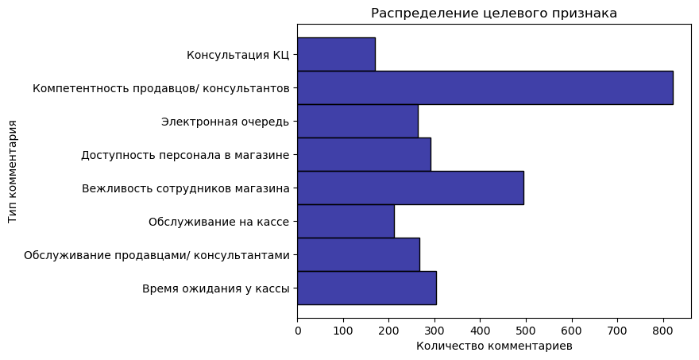

|  | Доля комментариев | Количество комментариев |
| --- | --- | --- |
| Компетентность продавцов/ консультантов | 0.290928 | 821 |
| Вежливость сотрудников магазина | 0.175408 | 495 |
| Время ожидания у кассы | 0.107725 | 304 |
| Доступность персонала в магазине | 0.103118 | 291 |
| Обслуживание продавцами/ консультантами | 0.094614 | 267 |
| Электронная очередь | 0.093196 | 263 |
| Обслуживание на кассе | 0.074770 | 211 |
| Консультация КЦ | 0.060241 | 170 |

```python
# Построение гистограммы распределения признака
sns.histplot(y=df['class'].astype(str), color='darkblue')
plt.title('Распределение целевого признака')
plt.xlabel('Количество комментариев');
plt.ylabel('Тип комментария')
plt.show()

# Вывод значений в виде таблицы
pd.DataFrame({'Доля комментариев': df['class'].value_counts(normalize=True),
              'Количество комментариев' : df['class'].value_counts()})
```

**Замечание:** В данных наблюдается явный дисбаланс классов. Возможно, нам потребуется бороться с ним при построении моделей машинного обучения.

### Посмотрим на длины текстов.

```python
# Регулярное выражение содержащее буквы на русском и английском языках и цифры
pattern = r'\w*[a-zA-Zа-яА-ЯёЁ0-9]+\w*'
```

```python
# Преобразование колонки с коментариями в список списков со словами из комментариев
text = []
for string in df['text']:
    text.append(re.findall(pattern, str(string)))
# Создание списка из длин комментариев
length_text = []
for comment in text:
    length_text.append(len(comment))
# Добавление информации в таблицу
df['length'] = length_text
```

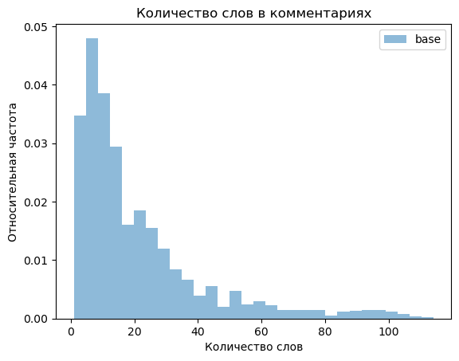

```
Минимальная и максимальная длины комментариев: 1 , 114
```

```python
# Построение гистограммы распределения комментариев по длинам
plt.hist(length_text, bins=30, alpha=0.5, density=True, label='base')
plt.legend(loc='upper right')
plt.xlabel('Количество слов');
plt.ylabel('Относительная частота');
plt.title('Количество слов в комментариях');
plt.show()
print('Минимальная и максимальная длины комментариев:', min(length_text), ',', max(length_text))
```

```python
# Информация по коротким коментариям
display(df[df['length'] < 3].sample(10))
display(df[df['length'] < 3]['class'].value_counts(normalize=True))
```

|  | id | text | class | length |
| --- | --- | --- | --- | --- |
| 1552 | 9637 | клиентоориентированности 0 | Компетентность продавцов/ консультантов | 2 |
| 1557 | 9665 | неприветливый персонал | Компетентность продавцов/ консультантов | 2 |
| 1787 | 11096 | компетентнее вежливее | Вежливость сотрудников магазина | 2 |
| 1595 | 9940 | навязывание услуг | Компетентность продавцов/ консультантов | 2 |
| 903 | 5532 | некомпетентные сотрудники ! | Компетентность продавцов/ консультантов | 2 |
| 545 | 3485 | навязывание допуслуг | Компетентность продавцов/ консультантов | 2 |
| 336 | 2043 | кассир хам | Обслуживание на кассе | 2 |
| 1758 | 10871 | вежливый кассир | Обслуживание на кассе | 2 |
| 1558 | 9674 | вежливость продавцов | Вежливость сотрудников магазина | 2 |
| 167 | 1145 | очередь кассе | Время ожидания у кассы | 2 |

```
Вежливость сотрудников магазина            0.290909
Компетентность продавцов/ консультантов    0.281818
Доступность персонала в магазине           0.127273
Обслуживание на кассе                      0.109091
Время ожидания у кассы                     0.100000
Консультация КЦ                            0.072727
Обслуживание продавцами/ консультантами    0.018182
Name: class, dtype: float64
```

```python
# Информация по длинным коментариям
display(df[df['length'] > 80].sample(10))
display(df[df['length'] > 80]['class'].value_counts(normalize=True))
```

|  | id | text | class | length |
| --- | --- | --- | --- | --- |
| 2148 | 13387 | товару 5+ . персоналу 0-. интернет заказ долже... | Компетентность продавцов/ консультантов | 94 |
| 2829 | 17557 | нужно указывать правильное количество товара м... | Консультация КЦ | 88 |
| 2214 | 13728 | подборе помогли , жаль знаю имён , консультант... | Обслуживание на кассе | 93 |
| 1792 | 11120 | хотел жаловаться , придется . пишите приложени... | Обслуживание на кассе | 90 |
| 1516 | 9419 | вместо данного интернет - заказа продали товар... | Компетентность продавцов/ консультантов | 84 |
| 738 | 4548 | пришёл заказом магазин 14 часов расчётом долго... | Электронная очередь | 93 |
| 2178 | 13559 | здравствуйте . сегодня забрала заказ кисловодс... | Обслуживание на кассе | 96 |
| 670 | 4200 | добрый день . хотел купить рассрочку планшет (... | Компетентность продавцов/ консультантов | 102 |
| 1588 | 9897 | сделал заказ . указанно . наличии магазине . и... | Компетентность продавцов/ консультантов | 82 |
| 2598 | 16134 | заказ отменен причине , 15 магазине работает п... | Вежливость сотрудников магазина | 97 |

```
Компетентность продавцов/ консультантов    0.393258
Вежливость сотрудников магазина            0.258427
Электронная очередь                        0.123596
Обслуживание на кассе                      0.112360
Консультация КЦ                            0.067416
Обслуживание продавцами/ консультантами    0.033708
Доступность персонала в магазине           0.011236
Name: class, dtype: float64
```

### Выполним частотный анализ текстов.

Результато этого анализа является список слов, наиболее часто встречающихся в тексте. Частотный анализ также позволяет получить представление о тематике и основных понятиях текста. Визуализировать его результаты удобно в виде "облака слов" (`WordCloud`). Эта диаграмма содержит слова, размер шрифта которых отражает их популярность в тексте.

Графики `WordCloud` будем строить на основе токенов. Токены получим с помощью метода `word_tokenize` из библиотеки `nltk`.

```python
# Разделение комментариев по классам
comp_sellers = (df[df['class'] == 'Компетентность продавцов/ консультантов']['text']
                .rename('Компетентность продавцов/ консультантов', inplace=True))

polite_staff = (df[df['class'] == 'Вежливость сотрудников магазина']['text']
                .rename('Вежливость сотрудников магазина', inplace=True))

time_checkout = (df[df['class'] == 'Время ожидания у кассы']['text']
                 .rename('Время ожидания у кассы', inplace=True))

available_staff  = (df[df['class'] == 'Доступность персонала в магазине']['text']
                    .rename('Доступность персонала в магазине', inplace=True))

service_sellers = (df[df['class'] == 'Обслуживание продавцами/ консультантами']['text']
                   .rename('Обслуживание продавцами/ консультантами', inplace=True))

electronic_queue = (df[df['class'] == 'Электронная очередь']['text']
                    .rename('Электронная очередь', inplace=True))

service_checkout = (df[df['class'] == 'Обслуживание на кассе']['text']
                    .rename('Обслуживание на кассе', inplace=True))

consultation = (df[df['class'] == 'Консультация КЦ']['text']
                .rename('Консультация КЦ', inplace=True))
```

```python
# Функция построения "облако слов"
def word_cloud(text, color='black'):
    # Распаковка вложенных списков в один
    extend_list_text = []
    for sublist in text:
        extend_list_text.extend(sublist.split())
    # Объединение всех токенов в одну строку
    str_text = " ".join(extend_list_text)
    # Построение графика "WordCloud"
    wordcloud_base = WordCloud(background_color=color, random_state=RANDOM_STATE).generate(str_text)
    plt.imshow(wordcloud_base)
    plt.axis('off')
    plt.title(f'Облако слов для комметариев класса \n "{text.name}"')
    plt.show()
```

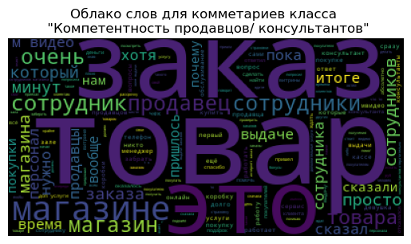

```python
word_cloud(comp_sellers, color='black')
```

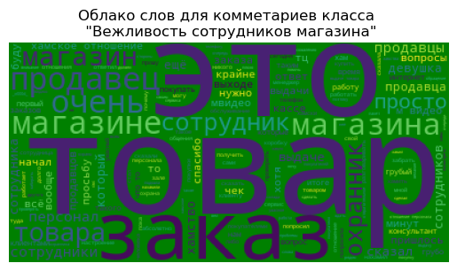

```python
word_cloud(polite_staff, color='green')
```

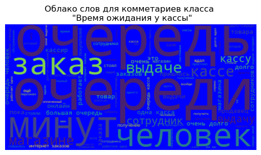

```python
word_cloud(time_checkout, color='blue')
```

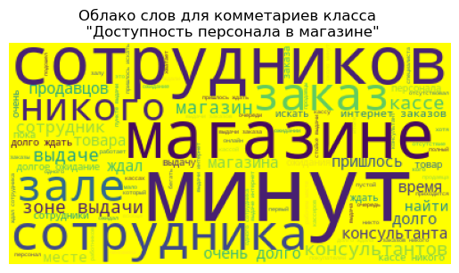

```python
word_cloud(available_staff, color='yellow')
```

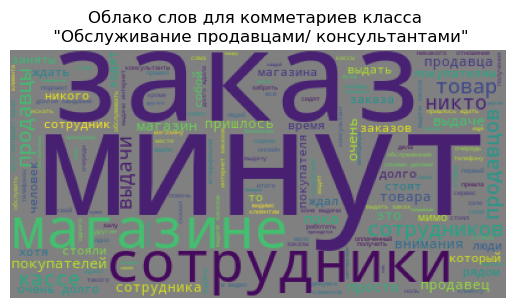

```python
word_cloud(service_sellers, color='gray')
```

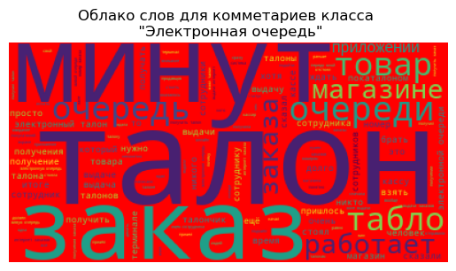

```python
word_cloud(electronic_queue, color='red')
```

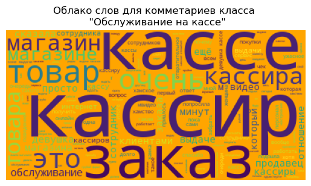

```python
word_cloud(service_checkout, color='orange')
```

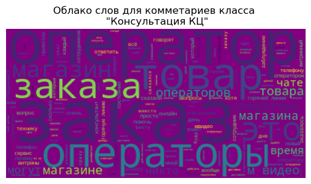

```python
word_cloud(consultation, color='purple')
```

**Замечание:**  
На графиках изображены наиболее распространённые слова в коментариях относящимся к определённым классам.

Мы видим, также, что существуют слова наиболее распространённые во всех классах одновременно. Например слово `заказ`.  
Возможно некоторые слова потребуется удалять из текстов комментариев для улучшения работы модели машинного обучения.

## Подготовка данных.

### Разделим данные на выборки.

# Кодирование целевого признака (при необходимости) le = LabelEncoder() df['class_le'] = le.fit_transform(df['class'])

```python
# Сохранение целевого признака в переменную target и текстов комментариев в переменную features
target = df['class']
features = df['text']
```

```python
# Разбиение данных на выборки
features_train, features_test, target_train, target_test = train_test_split(features,
                                                                            target,
                                                                            stratify=target,
                                                                            random_state=RANDOM_STATE,
                                                                            test_size=0.3)

# Вывод полученных размеров выборок на экран в виде таблицы
df_rezult = pd.DataFrame({'Shape': [features_train.shape,
                                    features_test.shape,
                                    target_train.shape,
                                    target_test.shape]},
                          index=['features_train',
                                 'features_test',
                                 'target_train',
                                 'target_test'])
display(df_rezult)
display(Markdown("<b>Баланс классов на тренировочной выборке</b>"))
print(target_train.value_counts(normalize=True))
display(Markdown('<b>Баланс классов на тестовой выборке</b>'))
print(target_test.value_counts(normalize=True))
```

|  | Shape |
| --- | --- |
| features_train | (1975,) |
| features_test | (847,) |
| target_train | (1975,) |
| target_test | (847,) |

**Баланс классов на тренировочной выборке**

```
Компетентность продавцов/ консультантов    0.290633
Вежливость сотрудников магазина            0.175190
Время ожидания у кассы                     0.107848
Доступность персонала в магазине           0.103291
Обслуживание продавцами/ консультантами    0.094684
Электронная очередь                        0.093165
Обслуживание на кассе                      0.074937
Консультация КЦ                            0.060253
Name: class, dtype: float64
```

**Баланс классов на тестовой выборке**

```
Компетентность продавцов/ консультантов    0.291617
Вежливость сотрудников магазина            0.175915
Время ожидания у кассы                     0.107438
Доступность персонала в магазине           0.102715
Обслуживание продавцами/ консультантами    0.094451
Электронная очередь                        0.093270
Обслуживание на кассе                      0.074380
Консультация КЦ                            0.060213
Name: class, dtype: float64
```

### Получим эмбединги из текстов с помощью `SentenceTransformer`.

Для преобразование текстов в эмбединги будем использовать предобученную модель `cointegrated/rubert-tiny2`, скаченную с сайта `Hugging Face`. После этого сохраним её в файл. Далее будем для использования модели будем загружать её локально.

# Инициализация модели с Hugging Face model_emb = SentenceTransformer('cointegrated/rubert-tiny2')# Сохранение модели в файл joblib.dump(model_emb, '../models/rubert-tiny2.pkl')

```python
# Загрузка модели из файла предварительно сохранённую с помощью joblib
model_emb = joblib.load('../models/rubert-tiny2.pkl')
```

```python
# Функция получения эмбедингов
def emb(text, model):
    '''
    text - преобразуемый текст в виде списка
    model - модель SentenceTransformer для получения эмбедингов
    '''
    database_vectors_emb = []
    # Получение эмбедингов
    for name  in notebook.tqdm(text):
        text_embedding = model.encode(name, convert_to_tensor=False)
        database_vectors_emb.append(text_embedding)
    return database_vectors_emb
```

```python
# Получение эмбедингов для base
train_emb = emb(features_train, model_emb)
# Вывод размеров эмбедингов для base
print(f'Размер base: {len(train_emb), len(train_emb[0])}')

# Получение эмбедингов для pars
test_emb = emb(features_test, model_emb)
# Вывод размеров эмбедингов для pars
print(f'Размер base: {len(test_emb), len(test_emb[0])}')
```

```
Размер base: (1975, 312)
```

```
Размер base: (847, 312)
```

**Замечание:** Длина вектора эмбедингов: 312.

## Обучение и анализ моделей.

Обучать модели и подбирать гиперпараметры будем с помощью модуля `optuna`. Также будем использовать метод кросс-валидации, со стратифицированным разделение данных на выборки.

Метрика качества будет `f1_macro`.

### Создадим функции для вывода метрик и графиков.

Обучать модели и подбтрать гиперпараметры будем на тренировочной выборке используя метод перекрёстной проверки.  
Для подбора гиперпараметров модели будем использовать фреймворк `Optuna`.

```python
# Функция вывода результатов проверки работы модели c помощью кросс - валидации
def report_confmatrix_f1_cv(model, features, target, cv=3, figsize=(8,6)):
    '''
    model - модель машинного обучения
    features - таблица признаков
    target - значения целевой переменной
    cv - количество фолдов в методе кросс-валидации
    figsize - размер графика
    '''
    # Получение предсказаний модели
    predict = cross_val_predict(model,
                                features,
                                target,
                                cv=cv)

    # Построение матрицы ошибок
    cm = confusion_matrix(target, predict)
    disp = ConfusionMatrixDisplay(confusion_matrix=cm)
    disp.plot()
    plt.show()

    # Вывод значений метрик классификации
    print(classification_report(target, predict))
```

```python
# Функция вывода результатов проверки работы модели
def report_confmatrix_f1(model, features, target, figsize=(8,6)):
    '''
    model - модель машинного обучения
    features - таблица признаков
    target - значения целевой переменной
    figsize - размер графика
    '''
    # Получение предсказаний модели
    predict = model.predict(features)

    # Построение матрицы ошибок
    cm = confusion_matrix(target, predict)
    disp = ConfusionMatrixDisplay(confusion_matrix=cm)
    disp.plot()
    plt.show()

    # Вывод значений метрик классификации
    print(classification_report(target, predict))
```

```python
# Переменная в которой хранится стратифицированный способ кросс-валидации
cv_st = StratifiedKFold(n_splits=3, random_state=RANDOM_STATE, shuffle=True)
```

### Исследуем модель классификации `LogisticRegression`.

```python
# Функция для обучения и предсказания модели с перебором гиперпараметров
def objective_1(trial, cv=3):
    # Создание переменной для перебора гиперпараметров
    params = {'max_iter': trial.suggest_int('max_iter', 10, 1000),
              'solver': trial.suggest_categorical('solver', ['lbfgs', 'liblinear', 'newton-cg', 'sag', 'saga'])}
    # Инициализация модели машинного обучения
    model = LogisticRegression(**params,
                               random_state=RANDOM_STATE,
                               class_weight='balanced')
    # Обучение и получение предсказаний модели (методом кросс-валидации)
    predict = cross_val_predict(model, train_emb, target_train, cv=cv_st, method='predict')
    # Возврат значения f1-score
    return f1_score(target_train, predict, average='macro')

# Обучение модели с перебором гиперпараметров с помощью модуля optuna максимизируя результат выполнения функици objective_1
study = optuna.create_study(direction='maximize')
study.optimize(objective_1, n_trials=10)
# Вывод оптимальных гиперпараметров модели
best_params_1 = study.best_params
print(best_params_1)
```

```
[I 2025-02-28 15:38:49,090] A new study created in memory with name: no-name-c5e68d7c-30de-45ae-a934-778a581cd685
[I 2025-02-28 15:38:50,072] Trial 0 finished with value: 0.6695088613862779 and parameters: {'max_iter': 221, 'solver': 'sag'}. Best is trial 0 with value: 0.6695088613862779.
[I 2025-02-28 15:38:51,073] Trial 1 finished with value: 0.6695088613862779 and parameters: {'max_iter': 157, 'solver': 'sag'}. Best is trial 0 with value: 0.6695088613862779.
[I 2025-02-28 15:38:51,194] Trial 2 finished with value: 0.6695088613862779 and parameters: {'max_iter': 411, 'solver': 'newton-cg'}. Best is trial 0 with value: 0.6695088613862779.
[I 2025-02-28 15:38:51,958] Trial 3 finished with value: 0.6695088613862779 and parameters: {'max_iter': 623, 'solver': 'saga'}. Best is trial 0 with value: 0.6695088613862779.
[I 2025-02-28 15:38:52,079] Trial 4 finished with value: 0.6695088613862779 and parameters: {'max_iter': 727, 'solver': 'newton-cg'}. Best is trial 0 with value: 0.6695088613862779.
[I 2025-02-28 15:38:53,018] Trial 5 finished with value: 0.6695088613862779 and parameters: {'max_iter': 179, 'solver': 'sag'}. Best is trial 0 with value: 0.6695088613862779.
[I 2025-02-28 15:38:53,962] Trial 6 finished with value: 0.6695088613862779 and parameters: {'max_iter': 982, 'solver': 'sag'}. Best is trial 0 with value: 0.6695088613862779.
[I 2025-02-28 15:38:54,082] Trial 7 finished with value: 0.6695088613862779 and parameters: {'max_iter': 915, 'solver': 'newton-cg'}. Best is trial 0 with value: 0.6695088613862779.
[I 2025-02-28 15:38:54,244] Trial 8 finished with value: 0.6695088613862779 and parameters: {'max_iter': 349, 'solver': 'lbfgs'}. Best is trial 0 with value: 0.6695088613862779.
[I 2025-02-28 15:38:54,408] Trial 9 finished with value: 0.6695088613862779 and parameters: {'max_iter': 182, 'solver': 'lbfgs'}. Best is trial 0 with value: 0.6695088613862779.
```

```
{'max_iter': 221, 'solver': 'sag'}
```

```python
# Сохранение модели машинного обучения с оптимальными гиперпараметрами
best_model_1 = LogisticRegression(**best_params_1,
                                  random_state=RANDOM_STATE,
                                  class_weight='balanced')
```

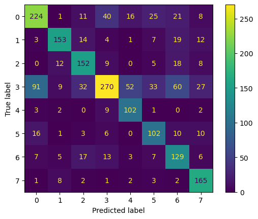

```
                                         precision    recall  f1-score   support

        Вежливость сотрудников магазина       0.65      0.65      0.65       346
                 Время ожидания у кассы       0.80      0.72      0.76       213
       Доступность персонала в магазине       0.66      0.75      0.70       204
Компетентность продавцов/ консультантов       0.77      0.47      0.58       574
                        Консультация КЦ       0.58      0.86      0.69       119
                  Обслуживание на кассе       0.56      0.69      0.62       148
Обслуживание продавцами/ консультантами       0.50      0.69      0.58       187
                    Электронная очередь       0.69      0.90      0.78       184

                               accuracy                           0.66      1975
                              macro avg       0.65      0.71      0.67      1975
                           weighted avg       0.68      0.66      0.65      1975
```

```python
# Вывод результатов проверки работы модели с помощью кросс - валидации на тренировочной выборке
report_confmatrix_f1_cv(best_model_1, train_emb, target_train, cv=cv_st)
```

### Исследуем модель классификации `RandomForestClassifier`.

```python
# Функция для обучения и предсказания модели с перебором гиперпараметров
def objective_2(trial, cv=3):
    # Создание переменной для перебора гиперпараметров
    params = {'criterion': trial.suggest_categorical('criterion', ['gini', 'entropy', 'log_loss']),
              'max_depth': trial.suggest_int('max_depth', 1, 30),
              'n_estimators': trial.suggest_int('n_estimators', 1, 100)}

    # Инициализация модели машинного обучения
    model = RandomForestClassifier(**params,
                                   random_state=RANDOM_STATE,
                                   class_weight='balanced')
    # Обучение и получение предсказаний модели (методом кросс-валидации)
    predict = cross_val_predict(model, train_emb, target_train, cv=cv_st, method='predict')
    # Возврат значения f1-score
    return f1_score(target_train, predict, average='macro')

# Обучение модели с перебором гиперпараметров с помощью модуля optuna максимизируя результат выполнения функици objective_1
study = optuna.create_study(direction='maximize')
study.optimize(objective_2, n_trials=10)
# Вывод оптимальных гиперпараметров модели
best_params_2 = study.best_params
print(best_params_2)
```

```
[I 2025-02-28 15:38:55,668] A new study created in memory with name: no-name-5cf18bbb-d8f4-488d-b2db-19806974cabd
[I 2025-02-28 15:39:00,801] Trial 0 finished with value: 0.43213394862065135 and parameters: {'criterion': 'entropy', 'max_depth': 25, 'n_estimators': 38}. Best is trial 0 with value: 0.43213394862065135.
[I 2025-02-28 15:39:08,044] Trial 1 finished with value: 0.44809707547861266 and parameters: {'criterion': 'log_loss', 'max_depth': 17, 'n_estimators': 54}. Best is trial 1 with value: 0.44809707547861266.
[I 2025-02-28 15:39:15,398] Trial 2 finished with value: 0.44015957413631757 and parameters: {'criterion': 'log_loss', 'max_depth': 20, 'n_estimators': 55}. Best is trial 1 with value: 0.44809707547861266.
[I 2025-02-28 15:39:23,653] Trial 3 finished with value: 0.4484311656756681 and parameters: {'criterion': 'gini', 'max_depth': 24, 'n_estimators': 82}. Best is trial 3 with value: 0.4484311656756681.
[I 2025-02-28 15:39:31,703] Trial 4 finished with value: 0.5773938104137708 and parameters: {'criterion': 'entropy', 'max_depth': 7, 'n_estimators': 75}. Best is trial 4 with value: 0.5773938104137708.
[I 2025-02-28 15:39:36,074] Trial 5 finished with value: 0.4397624796311881 and parameters: {'criterion': 'gini', 'max_depth': 17, 'n_estimators': 43}. Best is trial 4 with value: 0.5773938104137708.
[I 2025-02-28 15:39:36,250] Trial 6 finished with value: 0.2952385591336431 and parameters: {'criterion': 'gini', 'max_depth': 3, 'n_estimators': 5}. Best is trial 4 with value: 0.5773938104137708.
[I 2025-02-28 15:39:40,324] Trial 7 finished with value: 0.5226945475517756 and parameters: {'criterion': 'gini', 'max_depth': 5, 'n_estimators': 68}. Best is trial 4 with value: 0.5773938104137708.
[I 2025-02-28 15:39:46,432] Trial 8 finished with value: 0.4434010448830343 and parameters: {'criterion': 'gini', 'max_depth': 20, 'n_estimators': 60}. Best is trial 4 with value: 0.5773938104137708.
[I 2025-02-28 15:39:47,916] Trial 9 finished with value: 0.34955971203754466 and parameters: {'criterion': 'entropy', 'max_depth': 19, 'n_estimators': 11}. Best is trial 4 with value: 0.5773938104137708.
```

```
{'criterion': 'entropy', 'max_depth': 7, 'n_estimators': 75}
```

```python
# Сохранение модели машинного обучения с оптимальными гиперпараметрами
best_model_2 = RandomForestClassifier(**best_params_2,
                                      random_state=RANDOM_STATE,
                                      class_weight='balanced')
```

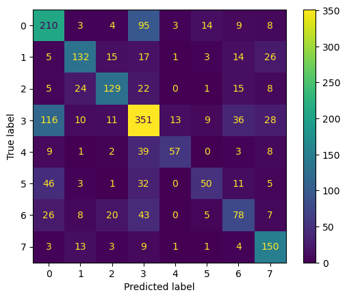

```
                                         precision    recall  f1-score   support

        Вежливость сотрудников магазина       0.50      0.61      0.55       346
                 Время ожидания у кассы       0.68      0.62      0.65       213
       Доступность персонала в магазине       0.70      0.63      0.66       204
Компетентность продавцов/ консультантов       0.58      0.61      0.59       574
                        Консультация КЦ       0.76      0.48      0.59       119
                  Обслуживание на кассе       0.60      0.34      0.43       148
Обслуживание продавцами/ консультантами       0.46      0.42      0.44       187
                    Электронная очередь       0.62      0.82      0.71       184

                               accuracy                           0.59      1975
                              macro avg       0.61      0.56      0.58      1975
                           weighted avg       0.59      0.59      0.58      1975
```

```python
# Вывод результатов проверки работы модели с помощью кросс - валидации на тренировочной выборке
report_confmatrix_f1_cv(best_model_2, train_emb, target_train, cv=cv_st)
```

### Исследуем модель классификации `LGBMClassifier`.

```python
# Функция для обучения и предсказания модели с перебором гиперпараметров
def objective_3(trial, cv=3):
    # Создание переменной для перебора гиперпараметров
    params = {'boosting_type': trial.suggest_categorical('boosting_type', ['gbdt', 'dart', 'goss']),
              'num_leaves': trial.suggest_int('num_leaves', 10, 1000),
              'max_depth': trial.suggest_int('max_depth', 1, 10),
              'learning_rate': trial.suggest_float('learning_rate', 0.01, 0.5),
              'n_estimators': trial.suggest_int('n_estimators', 10, 1000),
              'min_child_samples': trial.suggest_int('min_child_samples', 15, 100),
              'reg_alpha': trial.suggest_float('reg_alpha', 0.05, 0.5),
              'reg_lambda': trial.suggest_float('reg_lambda', 0.05, 0.5),
              'min_data_in_leaf': trial.suggest_int('min_data_in_leaf', 1, 1000),
              'lambda_l1': trial.suggest_float('lambda_l1', 1e-8, 10.0, log=True),
              'lambda_l2': trial.suggest_float('lambda_l2', 1e-8, 10.0, log=True),
              'min_gain_to_split': trial.suggest_float('min_gain_to_split', 0, 1.0),
              'feature_fraction': trial.suggest_float('feature_fraction', 0, 1.0),
              'bagging_fraction': trial.suggest_float('bagging_fraction', 0, 1.0)}

    # Инициализация модели машинного обучения
    model = LGBMClassifier(**params,
                           objective='multiclass',
                           num_class=8,
                           class_weight='balanced',
                           verbose=-1,
                           random_state=RANDOM_STATE)
    # Обучение и получение предсказаний модели (методом кросс-валидации)
    predict = cross_val_predict(model, train_emb, target_train, cv=cv_st, method='predict')
    # Возврат значения f1-score
    return f1_score(target_train, predict, average='macro')

# Обучение модели с перебором гиперпараметров с помощью модуля optuna максимизируя результат выполнения функици objective_1
study = optuna.create_study(direction='maximize')
study.optimize(objective_3, n_trials=10)
# Вывод оптимальных гиперпараметров модели
best_params_3 = study.best_params
print(best_params_3)
```

```
[I 2025-02-28 15:39:56,384] A new study created in memory with name: no-name-f3deb02d-1277-4235-9820-ac1de2a7cbdb
[I 2025-02-28 15:39:56,617] Trial 0 finished with value: 0.014207258834765998 and parameters: {'boosting_type': 'dart', 'num_leaves': 379, 'max_depth': 6, 'learning_rate': 0.012121267599811383, 'n_estimators': 449, 'min_child_samples': 87, 'reg_alpha': 0.10399471402099775, 'reg_lambda': 0.1253286928…
[I 2025-02-28 15:39:56,813] Trial 1 finished with value: 0.47436631711550625 and parameters: {'boosting_type': 'gbdt', 'num_leaves': 751, 'max_depth': 6, 'learning_rate': 0.4962925373309595, 'n_estimators': 11, 'min_child_samples': 54, 'reg_alpha': 0.27026411721294813, 'reg_lambda': 0.30915865352122…
[I 2025-02-28 15:39:56,944] Trial 2 finished with value: 0.014207258834765998 and parameters: {'boosting_type': 'goss', 'num_leaves': 996, 'max_depth': 1, 'learning_rate': 0.3935219340186873, 'n_estimators': 510, 'min_child_samples': 58, 'reg_alpha': 0.40232321104757945, 'reg_lambda': 0.181058908270…
[I 2025-02-28 15:39:57,401] Trial 3 finished with value: 0.27274866846442636 and parameters: {'boosting_type': 'goss', 'num_leaves': 121, 'max_depth': 6, 'learning_rate': 0.3580568509612965, 'n_estimators': 570, 'min_child_samples': 31, 'reg_alpha': 0.05922843833734048, 'reg_lambda': 0.4911862885078…
[I 2025-02-28 15:39:59,167] Trial 4 finished with value: 0.6537799975759493 and parameters: {'boosting_type': 'gbdt', 'num_leaves': 954, 'max_depth': 5, 'learning_rate': 0.29163018749648123, 'n_estimators': 697, 'min_child_samples': 51, 'reg_alpha': 0.2923988011668647, 'reg_lambda': 0.45550739168174…
[I 2025-02-28 15:40:05,917] Trial 5 finished with value: 0.6585166202531147 and parameters: {'boosting_type': 'dart', 'num_leaves': 42, 'max_depth': 3, 'learning_rate': 0.4734853074275767, 'n_estimators': 739, 'min_child_samples': 16, 'reg_alpha': 0.2947098147362965, 'reg_lambda': 0.1817976387576248…
[I 2025-02-28 15:40:10,962] Trial 6 finished with value: 0.6417637555130296 and parameters: {'boosting_type': 'dart', 'num_leaves': 307, 'max_depth': 2, 'learning_rate': 0.2179975171456069, 'n_estimators': 653, 'min_child_samples': 76, 'reg_alpha': 0.14414752534120245, 'reg_lambda': 0.18345924259006…
[I 2025-02-28 15:40:11,212] Trial 7 finished with value: 0.28494985723170296 and parameters: {'boosting_type': 'goss', 'num_leaves': 74, 'max_depth': 1, 'learning_rate': 0.32267702317970537, 'n_estimators': 274, 'min_child_samples': 84, 'reg_alpha': 0.11466948242693156, 'reg_lambda': 0.3808418758522…
[I 2025-02-28 15:40:12,841] Trial 8 finished with value: 0.6514642996592768 and parameters: {'boosting_type': 'goss', 'num_leaves': 628, 'max_depth': 4, 'learning_rate': 0.2806028868150785, 'n_estimators': 200, 'min_child_samples': 34, 'reg_alpha': 0.45096699712457006, 'reg_lambda': 0.16707078608699…
[I 2025-02-28 15:40:23,382] Trial 9 finished with value: 0.6488535298479287 and parameters: {'boosting_type': 'dart', 'num_leaves': 169, 'max_depth': 2, 'learning_rate': 0.09431152309885099, 'n_estimators': 621, 'min_child_samples': 77, 'reg_alpha': 0.292640231615739, 'reg_lambda': 0.455321493921671…
```

```
{'boosting_type': 'dart', 'num_leaves': 42, 'max_depth': 3, 'learning_rate': 0.4734853074275767, 'n_estimators': 739, 'min_child_samples': 16, 'reg_alpha': 0.2947098147362965, 'reg_lambda': 0.18179763875762484, 'min_data_in_leaf': 458, 'lambda_l1': 4.884817656098553e-06, 'lambda_l2': 2.0001919335734…
```

```python
# Сохранение модели машинного обучения с оптимальными гиперпараметрами
best_model_3 = LGBMClassifier(**best_params_3,
                              objective='multiclass',
                              num_class=8,
                              class_weight='balanced',
                              verbose=-1,
                              random_state=RANDOM_STATE)
```

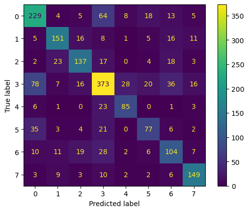

```
                                         precision    recall  f1-score   support

        Вежливость сотрудников магазина       0.62      0.66      0.64       346
                 Время ожидания у кассы       0.72      0.71      0.72       213
       Доступность персонала в магазине       0.69      0.67      0.68       204
Компетентность продавцов/ консультантов       0.69      0.65      0.67       574
                        Консультация КЦ       0.67      0.71      0.69       119
                  Обслуживание на кассе       0.58      0.52      0.55       148
Обслуживание продавцами/ консультантами       0.52      0.56      0.54       187
                    Электронная очередь       0.76      0.81      0.78       184

                               accuracy                           0.66      1975
                              macro avg       0.66      0.66      0.66      1975
                           weighted avg       0.66      0.66      0.66      1975
```

```python
# Вывод результатов проверки работы модели с помощью кросс - валидации на тренировочной выборке
report_confmatrix_f1_cv(best_model_3, train_emb, target_train, cv=cv_st)
```

**Вывод:** Лучшее качество показала линейная модель. Модель градиентного бустинга показала практически идентичное качество.

В качестве окончательно варианта примем линейную модель, ввиду её простоты и скорости работы.

## Проверка "лучшей" модели.

### Проверим качество итоговой модели на тестовой выборке.

После обучения модели, сохраним её в файл. Далее будем загружать её локально с компьютера.  
Обучим нашу модель на всей тренировочной выборке сразу.

# Выбор лучшей модели class_model = best_model_1# Обучение модели на всей тренировочной выборке сразу class_model.fit(train_emb, target_train)# Сохранение модели в файл joblib.dump(class_model, '../models/class_model.pkl')

```python
# Загрузка модели из файла
class_model = joblib.load('../models/class_model.pkl')
```

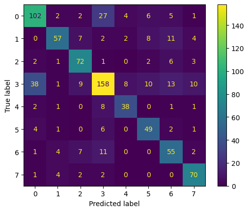

```
                                         precision    recall  f1-score   support

        Вежливость сотрудников магазина       0.68      0.68      0.68       149
                 Время ожидания у кассы       0.80      0.63      0.70        91
       Доступность персонала в магазине       0.73      0.83      0.77        87
Компетентность продавцов/ консультантов       0.73      0.64      0.68       247
                        Консультация КЦ       0.73      0.75      0.74        51
                  Обслуживание на кассе       0.65      0.78      0.71        63
Обслуживание продавцами/ консультантами       0.59      0.69      0.64        80
                    Электронная очередь       0.76      0.89      0.82        79

                               accuracy                           0.71       847
                              macro avg       0.71      0.73      0.72       847
                           weighted avg       0.71      0.71      0.71       847
```

```python
# Вывод результатов проверки работы модели на тестовой выборке
report_confmatrix_f1(class_model, test_emb, target_test)
```

**Замечание:** Модель показала качество лучше чем, на стадии кросс-валидации. Это объясняется тем, что мы обучили её на большем количестве данных (всей тренировочной выборке сразу). Некоторые классы модель определяет заметно хуже остальных. Переобучения не наблюдается.

### Проверим модель на адекватность.

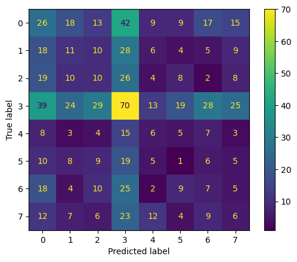

```
                                         precision    recall  f1-score   support

        Вежливость сотрудников магазина       0.17      0.17      0.17       149
                 Время ожидания у кассы       0.13      0.12      0.12        91
       Доступность персонала в магазине       0.11      0.11      0.11        87
Компетентность продавцов/ консультантов       0.28      0.28      0.28       247
                        Консультация КЦ       0.11      0.12      0.11        51
                  Обслуживание на кассе       0.02      0.02      0.02        63
Обслуживание продавцами/ консультантами       0.09      0.09      0.09        80
                    Электронная очередь       0.08      0.08      0.08        79

                               accuracy                           0.16       847
                              macro avg       0.12      0.12      0.12       847
                           weighted avg       0.16      0.16      0.16       847
```

```python
# Инициализация наивной моделиь с заданными гиперпараметрами
model_dummy_stratified = DummyClassifier(strategy='stratified', random_state=RANDOM_STATE)

# Обучение наивной модели на тренировочных данных
model_dummy_stratified.fit(train_emb, target_train)

# Вывод результатов проверки работы модели на тестовой выборке
report_confmatrix_f1(model_dummy_stratified, test_emb, target_test)
```

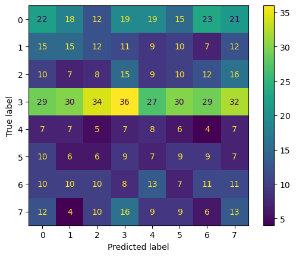

```
                                         precision    recall  f1-score   support

        Вежливость сотрудников магазина       0.19      0.15      0.17       149
                 Время ожидания у кассы       0.15      0.16      0.16        91
       Доступность персонала в магазине       0.08      0.09      0.09        87
Компетентность продавцов/ консультантов       0.30      0.15      0.20       247
                        Консультация КЦ       0.08      0.16      0.11        51
                  Обслуживание на кассе       0.09      0.14      0.11        63
Обслуживание продавцами/ консультантами       0.11      0.14      0.12        80
                    Электронная очередь       0.11      0.16      0.13        79

                               accuracy                           0.14       847
                              macro avg       0.14      0.14      0.14       847
                           weighted avg       0.18      0.14      0.15       847
```

```python
# Инициализация наивной моделиь с заданными гиперпараметрами
model_dummy_uniform = DummyClassifier(strategy='uniform', random_state=RANDOM_STATE)

# Обучение наивной модели на тренировочных данных
model_dummy_uniform.fit(features_train, target_train)

# Вывод результатов проверки работы модели на тестовой выборке
report_confmatrix_f1(model_dummy_uniform, features_test, target_test)
```

**Замечание:** Качество предсказания итоговой модели заметно лучше "константных". Наша итоговая модель прошла проверку на адекватность.

## Вывод.

В ходе работы мы выполнили, лёгкую предобработку текстов (удалили стоп-слова).Преобразовали тексты в эмбединги и обучили на них модели. Лучшее качество показала модель логистической регрессии. На тестовой выборке `f1_macro = 0.72`.

В дальнейшем можно заметно повысить качество предсказания модели ML. Для этого предлагается:

- Провести качественную предобработку текстов, на основе более внимательного анализа.
- Можно использовать другие предобученные модели для получения эмбедингов из текстов.
- Можно дообучить эту модель на имеющихся текстах. Таким образом получится учитывать тематику текстов (бизнес, продажи и т.д.)
- После этих улучшений, качество работы градиентных бустингов должно повыситься.
- Также можно использовать нейронные сети.